# Introduction to moimix package

Stuart Lee

2016-03-23

# Contents

Estimating multiple infections from variant data obtained using massively parallel sequencing experiments can be done in several ways using `moimix`.

The core function in `moimix` is `binomix` which is an interface to a binomial mixture model estimation procedure using the R package `flexmix`. The input to this function is a matrix of read counts supporting the reference and alternate alleles for all the variants in data.

In this vignette, we will introduce some key functions in `moimix` and how to set up your variant data to estimate some measures of multiplicity of infection.

## 0.1 Key functions in `moimix`

| Function | Description |
| --- | --- |
| binommix | estimate MOI using binomial mixture model |
| alleleCounts | extract a matrix of read counts |
| getBAF | estimate B-allele frequencies from read counts |
| plotBAF | plot the B-allele frequency spectra genome-wide |
| getMAF | esimate minor allele frequencies from read counts |
| getFws | estimate within isolate diversity according to Manske et. al, 2012 |
| callMajor | call major haplotypes using B-allele frequencies |
| extractCOIL | Output a COIL barcode file |
| extractPED | Create haploid PLINK PED file |

## 0.2 Data Formats

`moimix` assumes that variants have been called either from whole-genome/exome or RNA sequencing and the variant calling algorithm used outputs a variant call format (VCF) version 4.1 file. We also assume that each sample in the VCF file has been annotated with a AD tag at the variant sites for both the alternate and reference alleles. Currently, we have tested the functions using output from GATK UnifiedGenotyper and HaplotypeCaller algorithms.

`moimix` requires that the VCF file is then converted to the Genomic Data Storage (GDS) format. The GDS format provides a fast and convienent way of manipulating large VCF files in R. We make use of the `SeqArray` package for both VCF conversion and manipulating GDS files.

If you are just interested in running the binomix procedure, then you do not need to have a GDS file. For each sample construct a matrix with 2 columns correpsonding the read counts for the alternate and referene alleles. Then pass this matrix to the `binomix` function.

### 0.2.1 Converting a VCF to GDS format

To convert a tabixed gzipped VCF file to the GDS format use the `SeqArray` package.

```r
library(SeqArray)
seqVCF2GDS("/path/to/my/file.vcf.gz", "/path/to/my/file.gds")
```

To read the GDS file into R, use the `seqOpen` function and to check that its output matches the orginal VCF file use seqSummary.

```r
my_vcf <-seqOpen("/path/to/my/file.gds")
seqSummary(my_vcf)
```

# 1 Case study: *Plasmodium falciparum* isolates from The Gambia.

Here we present an example analysis from data obtained from the [Malaria Genomics Consoritum](https://www.malariagen.net/projects/parasite/pf) community project. The data consists of 65 *Plasmodium falciparum* isolates from The Gambia with approximately 78,000 high-quality biallelic SNVs on 14 nuclear chromosomes and the apicoplast.

For details on how the data was processed please see the README file located at ftp://ngs.sanger.ac.uk/production/pf3k/release_4/

First, we use `SeqArray` to load our GDS file and look at it.

```r
library(SeqArray)
gds_file <- system.file("extdata", "gambian_isolates.gds", package = "moimix")
isolates <- seqOpen(gds_file)
seqSummary(isolates)
```

```
## File: /Users/lee.s/Library/R/3.2/library/moimix/extdata/gambian_isolates.gds
## Format Version: v1.0
## Reference: file:///lustre/scratch109/malaria/pf3k_methods/resources/Pfalciparum.genome.fasta
## Ploidy: 2
## Number of samples: 65
## Number of variants: 77241
## Chromosomes:
##  Pf3D7_01_v3  Pf3D7_02_v3  Pf3D7_03_v3  Pf3D7_04_v3  Pf3D7_05_v3
##         2040         2781         3256         4518         4540
##  Pf3D7_06_v3  Pf3D7_07_v3  Pf3D7_08_v3  Pf3D7_09_v3  Pf3D7_10_v3
##         3942         4881         4709         4791         5595
##  Pf3D7_11_v3  Pf3D7_12_v3  Pf3D7_13_v3  Pf3D7_14_v3 Pf3D7_API_v3
##         6915         6905        10117        12205           46
##         <NA>
##            0
## Number of alleles per site:
##     2
## 77241
## Annotation, INFO variable(s):
##  AC, A, Integer, Allele count in genotypes, for each ALT allele, in the same order as listed
##  AF, A, Float, Allele Frequency, for each ALT allele, in the same order as listed
##  AN, 1, Integer, Total number of alleles in called genotypes
##  BaseQRankSum, 1, Float, Z-score from Wilcoxon rank sum test of Alt Vs. Ref base qualities
##  ClippingRankSum, 1, Float, Z-score From Wilcoxon rank sum test of Alt vs. Ref number of hard clipped bases
##  DP, 1, Integer, Approximate read depth; some reads may have been filtered
##  DS, 0, Flag, Were any of the samples downsampled?
##  END, 1, Integer, Stop position of the interval
##  FS, 1, Float, Phred-scaled p-value using Fisher's exact test to detect strand bias
##  GC, 1, Float, GC content around the variant (see docs for window size details)
##  HaplotypeScore, 1, Float, Consistency of the site with at most two segregating haplotypes
##  InbreedingCoeff, 1, Float, Inbreeding coefficient as estimated from the genotype likelihoods per-sample when compared against the Hardy-Weinberg expectation
##  MLEAC, A, Integer, Maximum likelihood expectation (MLE) for the allele counts (not necessarily the same as the AC), for each ALT allele, in the same order as listed
##  MLEAF, A, Float, Maximum likelihood expectation (MLE) for the allele frequency (not necessarily the same as the AF), for each ALT allele, in the same order as listed
##  MQ, 1, Float, RMS Mapping Quality
##  MQRankSum, 1, Float, Z-score From Wilcoxon rank sum test of Alt vs. Ref read mapping qualities
##  NEGATIVE_TRAIN_SITE, 0, Flag, This variant was used to build the negative training set of bad variants
##  POSITIVE_TRAIN_SITE, 0, Flag, This variant was used to build the positive training set of good variants
##  QD, 1, Float, Variant Confidence/Quality by Depth
##  RPA, ., Integer, Number of times tandem repeat unit is repeated, for each allele (including reference)
##  RU, 1, String, Tandem repeat unit (bases)
```

[output cut: 15 more lines]

```
##  culprit, 1, String, The annotation which was the worst performing in the Gaussian mixture model, likely the reason why the variant was filtered out
##  set, 1, String, Source VCF for the merged record in CombineVariants
##  PRA, 1, String, Plasmodium reichenowi allele
## Annotation, FORMAT variable(s):
##  AD, ., Integer, Allelic depths for the ref and alt alleles in the order listed
##  DP, 1, Integer, Approximate read depth (reads with MQ=255 or with bad mates are filtered)
##  GQ, 1, Integer, Genotype Quality
##  MIN_DP, 1, Integer, Minimum DP observed within the GVCF block
##  PGT, 1, String, Physical phasing haplotype information, describing how the alternate alleles are phased in relation to one another
##  PID, 1, String, Physical phasing ID information, where each unique ID within a given sample (but not across samples) connects records within a phasing group
##  PL, G, Integer, Normalized, Phred-scaled likelihoods for genotypes as defined in the VCF specification
##  RGQ, 1, Integer, Unconditional reference genotype confidence, encoded as a phred quality -10*log10 p(genotype call is wrong)
##  SB, 4, Integer, Per-sample component statistics which comprise the Fisher's Exact Test to detect strand bias.
## Annotation, sample variable(s):
##
```

```r
# save sample identifiers
sample.id <- seqGetData(isolates, "sample.id")
```

We also filter the variants located on the apicoplast before any downstream analysis.

```r
library(moimix)
# get genomic coordinates of all variants
coords <- getCoordinates(isolates)
head(coords)
```

```
##    chromosome position variant.id
## 1 Pf3D7_02_v3   106099          1
## 2 Pf3D7_02_v3   106230          2
## 3 Pf3D7_02_v3   108524          3
## 4 Pf3D7_02_v3   108889          4
## 5 Pf3D7_02_v3   109059          5
## 6 Pf3D7_02_v3   109073          6
```

```r
# filter variant.ids not on apicoplast
seqSetFilter(isolates,
             variant.id = coords$variant.id[coords$chromosome != "Pf3D7_API_v3"])
```

```
## # of selected variants: 77195
```

## 1.1 Estimating the BAF matrix

The first step in our clonality analysis is to estiamte the B-allele frequencies for each isolate directly from the sequencing depth. We construct a `bafMatrix` object which stores the estimates of the B-allele frequencies in a matrix over the entire cohort and the genomic coordinates of the variants.

```r
isolate_baf <- bafMatrix(isolates)
class(isolate_baf)
```

```
## [1] "bafMatrix"
```

```r
str(isolate_baf)
```

```
## List of 2
##  $ baf_matrix: num [1:65, 1:77195] 0 0 0 0 0 0 0 0 0 0 ...
##   ..- attr(*, "dimnames")=List of 2
##   .. ..$ sample : chr [1:65] "PA0007-C" "PA0008-C" "PA0011-C" "PA0012-C" ...
##   .. ..$ variant: chr [1:77195] "1" "2" "3" "4" ...
##  $ coords    :'data.frame':  77195 obs. of  3 variables:
##   ..$ chromosome: chr [1:77195] "Pf3D7_02_v3" "Pf3D7_02_v3" "Pf3D7_02_v3" "Pf3D7_02_v3" ...
##   ..$ position  : int [1:77195] 106099 106230 108524 108889 109059 109073 109248 109343 109601 109623 ...
##   ..$ variant.id: int [1:77195] 1 2 3 4 5 6 7 8 9 10 ...
##  - attr(*, "class")= chr "bafMatrix"
```

You can plot the genome-wide B-allele frequencies by passing the `bafMatrix` object and a sample identifer to `plot`.

Here’s an example for an isolate that is from a single-clone infection.

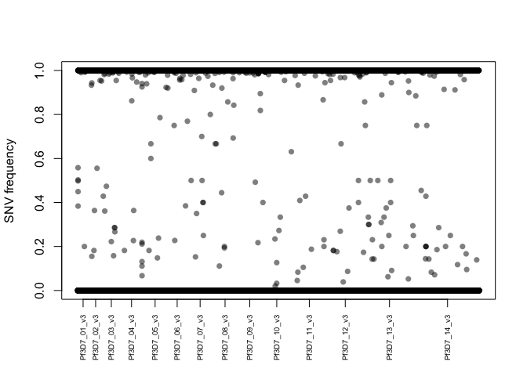

```r
plot(isolate_baf, "PA0022-C")
```

And an example of multiple-clone infection.

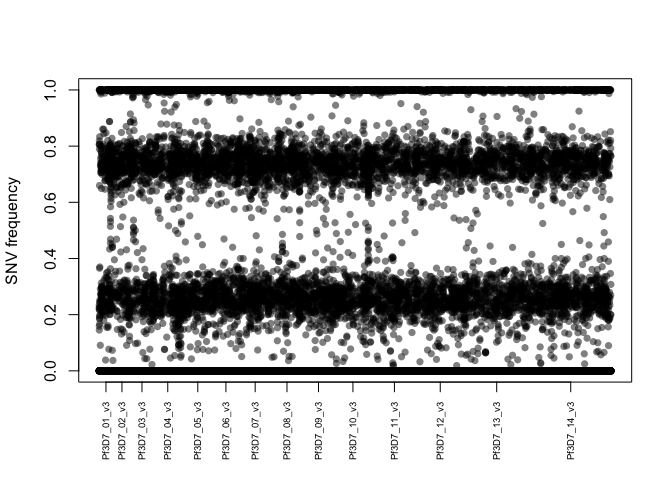

```r
plot(isolate_baf,  "PA0021-C")
```

## 1.2 Estimating MOI with `binommix`

```r
set.seed(2002)
# first generate matrix of read counts for ref and alt alleles
counts <- alleleCounts(isolates)

# fit a model on sample PA0021-C, multiple clone infection
m1 <- binommix(counts, sample.id = "PA0021-C", k = 2)
```

```
## 2 : * * * * * * * * * *
```

```r
# to inspect the model and view parameter estimates
summary(m1)
```

```
##
## Call:
## flexmix::initFlexmix(y_obs ~ 1, model = flexmix::FLXMRglm(y_obs ~
##     ., family = "binomial"), k = 2, control = list(iter.max = niter,
##     minprior = 0), nrep = 10)
##
##        prior size post>0 ratio
## Comp.1 0.496 4081   4125 0.989
## Comp.2 0.504 4143   4199 0.987
##
## 'log Lik.' -38145.25 (df=3)
## AIC: 76296.51   BIC: 76317.55
```

```r
param.estimates <- getTheta(m1)
param.estimates
```

```
##      pi.hat    mu.hat
## 1 0.4960888 0.2559665
## 2 0.5039112 0.7484539
```

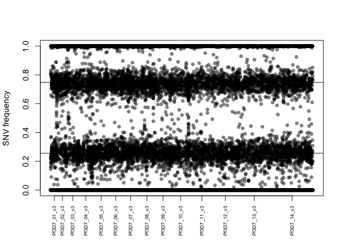

```r
# visualise model output
plot(isolate_baf, "PA0021-C")
abline(h = param.estimates$mu.hat)
```

## 1.3 Estimating MOI with $F_{ws}$

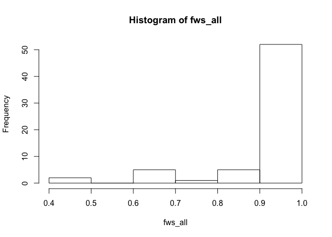

```r
fws_all <- getFws(isolates)

hist(fws_all)
```

```r
# see if our sample that we estimated is multiclonal according to fws
fws_all["PA0021-C"] < 0.95
```

```
## PA0021-C
##     TRUE
```

# 3 References

1. flexmix package - https://cran.r-project.org/web/packages/flexmix/index.html
2. SeqArray package - http://bioconductor.org/packages/release/bioc/html/SeqArray.html